# Turtle Cohort Summary

Grace Faulkner

2024-01-31

## Turtle Rescue Team AMR Cohort Summary

Antibiotic Resistance (AR) can be found beyond healthcare settings and presents a One Health challenge, impacting human, animal, and environmental health. Wildlife could serve as sentinels for AR in the environment. AR has been described in chelonians, including marine, freshwater, and terrestrial species, suggesting that wildlife and their environments could be bioindicators of AR pollution and transmission.

The bacterial flora of North Carolina (NC) wild turtles is not well-understood, and the presence and characteristics of resistant bacteria in this population have not been previously described. Rhea Lab conducted a pilot study to assess the feasibility of using admitted NC State University (NCSU) Turtle Rescue Team (TRT) native NC turtle patients as bioindicators of local AR in the environment.

Rhea Lab in collaboration with the North Carolina State University College of Veterinary Medicine Turtle Rescue Team (TRT) collected turtle demographic information and biological cloacal samples during TRT Intake and Discharge Procedures from admitted turtles from April 1,2023 to June 30, 2023 at NCSU CVM TRT. The study consisted of rolling admissions of hospitalized turtle cases. Inclusion criteria included surrender to TRT and native NC testudine species. Cloacal samples were processed with a focus on isolation of Escherichia coli (E. coli) and Salmonella, due to their presence in turtle GI flora and the environment, pathogenic potential in humans and animals, and demonstrated AR.

The study goals were 1).Identify the presence of and characterize antimicrobial resistant bacteria among TRT turtles and 2). Assess the feasibility of using admitted TRT native NC turtle patients as bioindicators of local antimicrobial resistance in the environment.

**This is preliminary data and does not support final conclusions.**

## Turtle Cohort

```r
##How many turtles are in the study cohort
nrow(Dashboard)
```

```
## [1] 102
```

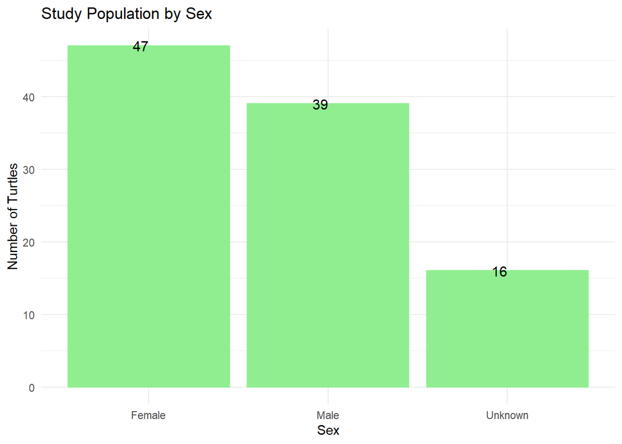

```r
##How many males/females in the study cohort
ggplot(data=Dashboard, aes(x=Sex)) + geom_bar(color="lightgreen", fill= "lightgreen") + theme_minimal() + ggtitle("Study Population by Sex") + ylab("Number of Turtles") + scale_x_discrete(labels=c("F"= "Female", "M"="Male", "UNK"= "Unknown")) + geom_text(stat='count', aes(label=..count..), hjust=1, size=4)
```

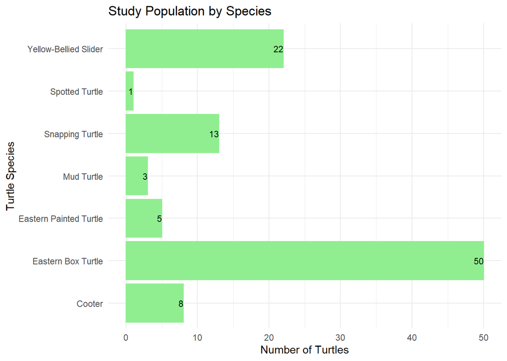

```r
##What is the species breakdown
ggplot(data=EpiInfo, aes(x=TurtleSpecies)) + geom_bar(color="lightgreen", fill="lightgreen") + theme_minimal() + ggtitle("Study Population by Species") + ylab("Number of Turtles") + xlab("Turtle Species") + coord_flip() + geom_text(stat='count', aes(label=..count..), hjust=1, size=3)
```

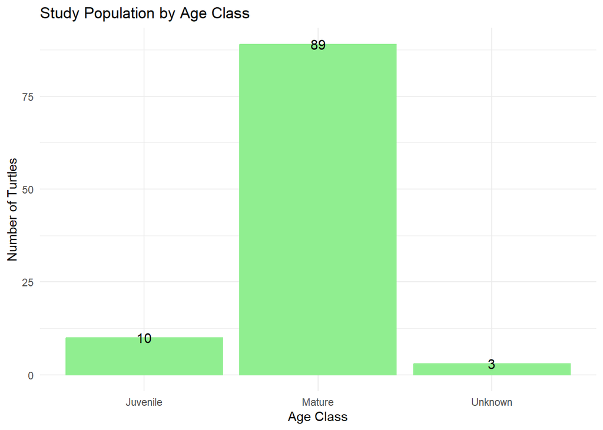

```r
##What is the age class distribution
ggplot(data=EpiInfo, aes(x=Ageclass)) + geom_bar(color="lightgreen", fill="lightgreen") + theme_minimal() + ggtitle("Study Population by Age Class") + xlab("Age Class") + ylab("Number of Turtles") + geom_text(stat='count', aes(label=..count..), hjust=.5, size=4)
```

```r
##How many turtles came from each county
table(Dashboard['County'])
```

```
## County
##    Almance   Beaufort     Bladen    Chatham Cumberland     Durham  Edgecombe
##          6          1          1          4          2         10          2
##    Forsyth   Franklin  Granville   Guilford    Halifax    Harnett   Johnston
##          1          5          1          3          1          4          2
##        Lee     Orange    Pamlico       Wake
##          3         13          1         31
```

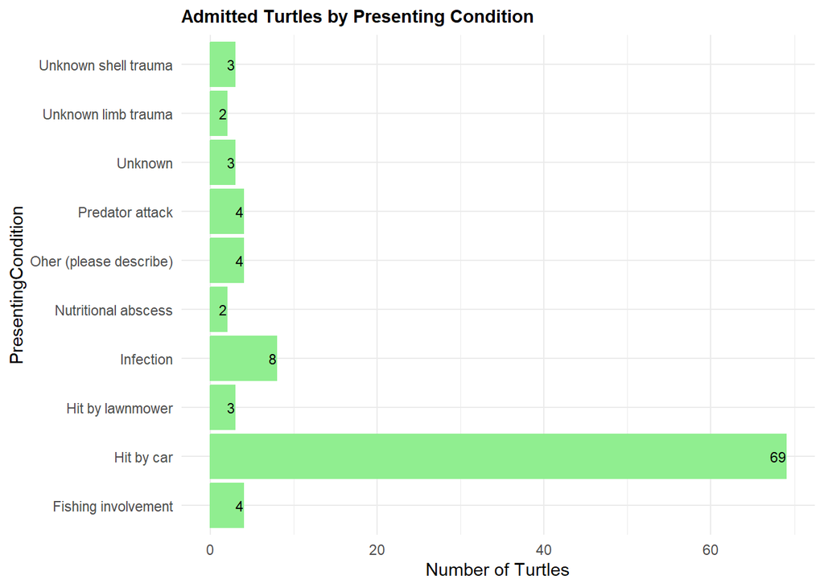

```r
#Plot presenting conditions
ggplot(data=EpiInfo, aes(x=PresentingCondition)) + geom_bar(color="lightgreen", fill="lightgreen") + theme_minimal() + ggtitle("Admitted Turtles by Presenting Condition") + ylab("Number of Turtles") + coord_flip() + geom_text(stat='count', aes(label=..count..), hjust=1, size=3) + theme(plot.title = element_text(hjust = 0, size=11, face="bold"))
```

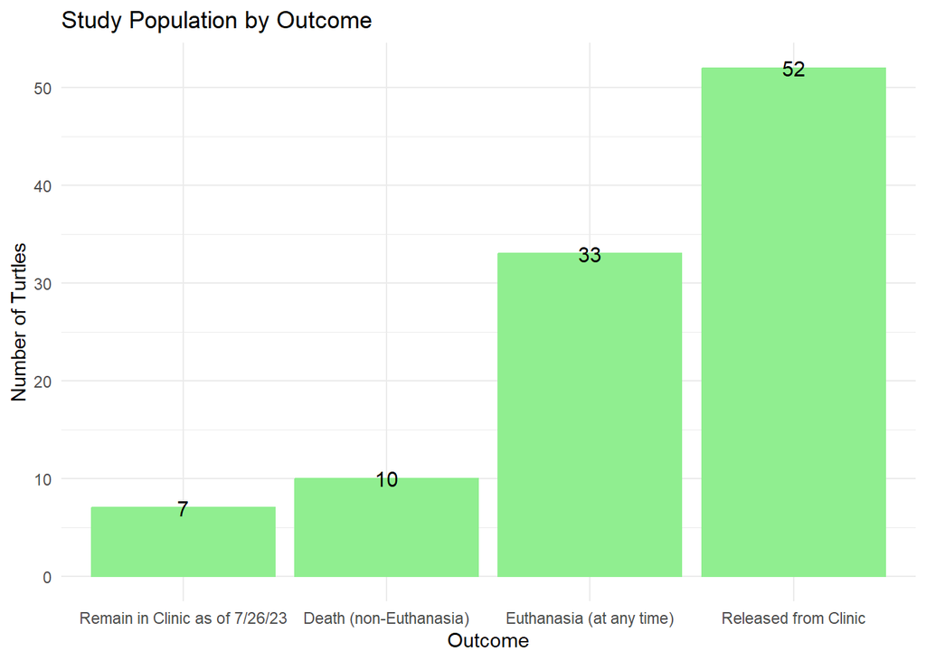

```r
#Plot Outcomes
ggplot(data=Dashboard, aes(x=Outcome)) + geom_bar(color="lightgreen", fill="lightgreen")+ theme_minimal() +ggtitle("Study Population by Outcome") + ylab("Number of Turtles") + scale_x_discrete(labels=c("C"= "Remain in Clinic as of 7/26/23", "D"="Death (non-Euthanasia)", "E"= "Euthanasia (at any time)", "R"= "Released from Clinic")) + geom_text(stat='count', aes(label=..count..), vjust=.5, size=4)
```

## Sample Collection

During intake and before discharge, each cohort member was swabbed for a cloacal sample. There were 93 samples collected at Intake and 42 samples collected at Discharge.

```r
##How many cloacal samples were collected at intake
table(Dashboard['IntakeCollected'])
```

```
## IntakeCollected
##  No Yes
##   9  93
```

```r
##How many cloacal samples were collected at discharge
table(Dashboard['DischargeCollected'])
```

```
## DischargeCollected
##  No Yes
##  60  42
```

## Antibiotic Usage

At the clinic, the turtles could be treated with antibiotics, which could introduce AR or AR pollution in the environment. Of those admitted to the cohort, 58 turtles were treated with antibiotics. Most turtles were treated with antibiotics due to fractures. Ceftazidime was the most commonly used antibiotic.

```r
##How many turtles were treated with Antibiotics
table(Dashboard['AntibtioticsAdministered'])
```

```
## AntibtioticsAdministered
##  N  Y
## 44 58
```

```r
##What was the purpose of antibiotic
table(EpiInfo$PurposeofAntimicrobial)
```

```
##
##                                         Fractures
##                                                21
##                                   Infected wounds
##                                                 6
## Injury with coelomic breach (or suspected breach)
##                                                 3
##                                             Other
##                                                19
##                                            Sepsis
##                                                 1
##                                             Viral
##                                                 4
```

```r
table(EpiInfo$PurposeofAntimicrobial2)
```

```
##
## Fractures     Other     Viral
##         2         4         2
```

```r
##What antibiotics were used
table(EpiInfo$AntimicrobialDrug)
```

```
##
##              Ceftazidime Ophthalmic ciprofloxacin                    Other
##                       39                        4                       12
##          Oxytetracycline
##                        3
```

```r
##antibiotic use by outcome
table(Dashboard$`AntibtioticsAdministered`, Dashboard$Outcome)
```

```
##
##      C  D  E  R
##   N  0  3 30 11
##   Y  7  7  3 41
```